# Reproducible Research - Exploring & Analyzing NOAA Storm Database

### Author: Himanshu Rawat

### Date: 20th June, 2015

- Synopsis
- Data Processing
  - FATALITIES Processing
  - INJURIES Processing
  - ECONOMIC Processing
- Results

## Synopsis

The basic goal of this assignment is to explore NOAA Storm Database for the severity of the weather events. We will also answer below questions:

- Across the United States, which types of events (as indicated in the EVTYPE variable) are most harmful with respect to population health?
- Across the United States, which types of events have the greatest economic consequences?

[Storm Data](http://d396qusza40orc.cloudfront.net/repDF%2FDF%2FStormDF.csv.bz2)

## Data Processing

I am assuminng data has been downloaded and extracted via above link and configured correct current working directory.  
Load neccessary packages.

```r
library(package = "plyr", warn.conflicts = FALSE, quietly = TRUE)
```

```r
library(package = "dplyr", warn.conflicts = FALSE, quietly = TRUE)
library(package = "ggplot2", warn.conflicts = FALSE, quietly = TRUE)
```

Simple read of CSV file as we need to see all the variables. I will limit to 10 rows.

```r
storm.data <- read.csv(file ="repdata_data_StormData.csv", nrow = 10)
str(storm.data)
```

```
## 'data.frame':    10 obs. of  37 variables:
##  $ STATE__   : num  1 1 1 1 1 1 1 1 1 1
##  $ BGN_DATE  : Factor w/ 7 levels "1/22/1952 0:00:00",..: 6 6 5 7 2 2 3 1 4 4
##  $ BGN_TIME  : int  130 145 1600 900 1500 2000 100 900 2000 2000
##  $ TIME_ZONE : Factor w/ 1 level "CST": 1 1 1 1 1 1 1 1 1 1
##  $ COUNTY    : num  97 3 57 89 43 77 9 123 125 57
##  $ COUNTYNAME: Factor w/ 9 levels "BALDWIN","BLOUNT",..: 7 1 4 6 3 5 2 8 9 4
##  $ STATE     : Factor w/ 1 level "AL": 1 1 1 1 1 1 1 1 1 1
##  $ EVTYPE    : Factor w/ 1 level "TORNADO": 1 1 1 1 1 1 1 1 1 1
##  $ BGN_RANGE : num  0 0 0 0 0 0 0 0 0 0
##  $ BGN_AZI   : logi  NA NA NA NA NA NA ...
##  $ BGN_LOCATI: logi  NA NA NA NA NA NA ...
##  $ END_DATE  : logi  NA NA NA NA NA NA ...
##  $ END_TIME  : logi  NA NA NA NA NA NA ...
##  $ COUNTY_END: num  0 0 0 0 0 0 0 0 0 0
```

[output cut: 23 more lines]

Our raw storm data consists of `37` columns but we are interested in `8` columns i.e.

| Variale name | Description |
| --- | --- |
| STATE | Two letter code |
| EVTYPE | Weather event source type (tornado,avalanche,ice-storm etc.) |
| FATALITIES | Count of weather event related fatalities |
| INJURIES | Count of weather event related injuries |
| PROPDMG | Property damage (scaled value) |
| PROPDMGEXP | Unit of measure for the PROPDMG |
| CROPDMG | Crop damage (scaled value) |
| CROPDMGEXP | Unit of measure for CROPDMG |

Lets read only above columns

```r
columns.to.read <- c(rep("NULL",6), rep("character",2) ,
                        rep("NULL",14),rep("numeric",3),"character","numeric","character", rep("NULL",9))

storm.data <- read.csv(file ="repdata_data_StormData.csv", colClasses = columns.to.read , nrow = 1232705)
```

### Pre process the data for simplifications

```r
# for every state, get the total counts of each event type
new.storm <- storm.data %>% group_by(STATE,EVTYPE) %>% summarise(fatal.count = sum(FATALITIES), injur.count = sum(INJURIES), total.count = sum(FATALITIES + INJURIES))
```

Harmful events across the states w.r.t population health can be divided into two parts

1. FATALITIES
2. INJURIES

Economic consequences will use below columns

1. PROPDMG
2. PROPDMGEXP
3. CROPDMG
4. CROPDMGEXP

### `FATALITIES` Processing

```r
# get the event have max count and remove duplicates
fatal <- new.storm %>% top_n(n = 1, wt = fatal.count) %>% distinct()
# summarise the total count of each event. This will give us unqiue fatalities.
fatal.new <- fatal %>% group_by(EVTYPE) %>% summarise(total.count = sum (fatal.count))
# sort them in decreasing order
fatal.new <- fatal.new[order(fatal.new$total.count, decreasing = TRUE),]
fatal.new
```

```
## Source: local data frame [19 x 2]
##
##                      EVTYPE total.count
## 1                   TORNADO        5118
## 2            EXCESSIVE HEAT         716
## 3                      HEAT         709
## 4                 AVALANCHE         199
## 5               RIP CURRENT         192
## 6               FLASH FLOOD         136
## 7                   TSUNAMI          32
## 8                 HIGH WIND          25
## 9                 HIGH SURF          24
## 10                LIGHTNING          15
## 11       MARINE STRONG WIND           9
## 12 MARINE THUNDERSTORM WIND           7
## 13         MARINE TSTM WIND           6
## 14                TSTM WIND           6
## 15                    FLOOD           4
## 16              MARINE HAIL           0
## 17         MARINE HIGH WIND           0
## 18             STRONG WINDS           0
## 19               WATERSPOUT           0
```

### `FATALITIES` plot

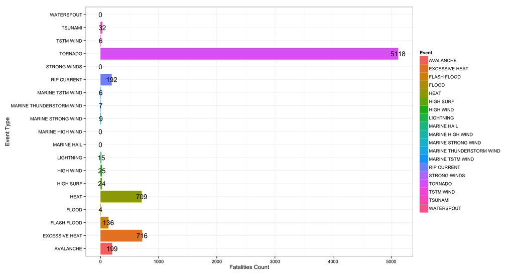

```r
g <- ggplot(data = fatal.new, aes(x = fatal.new$EVTYPE, y = fatal.new$total.count, fill=fatal.new$EVTYPE))
g <- g + geom_bar(stat = "identity") + scale_fill_hue(c=45, l=80)
g <- g + geom_text(aes(label = fatal.new$total.count, y = fatal.new$total.count))
g <- g + coord_flip()
g <- g + scale_fill_discrete(name="Event")
g <- g + xlab("Event Type") +  ylab("Fatalities Count")
g <- g + theme_bw()
g
```

### `INJURIES` Processing

```r
# get the event have max count and remove duplicates
injur <- new.storm %>% top_n(n = 1, wt = injur.count) %>% distinct()
# summarise the total count of each event. This will give us unqiue injuries.
injur.new <- injur %>% group_by(EVTYPE) %>% summarise(total.count = sum (injur.count))
# sort them in decreasing order
injur.new <- injur.new[order(injur.new$total.count, decreasing = TRUE),]
injur.new
```

```
## Source: local data frame [23 x 2]
##
##               EVTYPE total.count
## 1            TORNADO       90319
## 2     EXCESSIVE HEAT        1077
## 3           WILDFIRE         623
## 4       WINTER STORM         534
## 5  HURRICANE/TYPHOON         333
## 6         DUST STORM         179
## 7          TSTM WIND         166
## 8          LIGHTNING         156
## 9            TSUNAMI         129
## 10 THUNDERSTORM WIND          74
## ..               ...         ...
```

### `INJURIES` plot

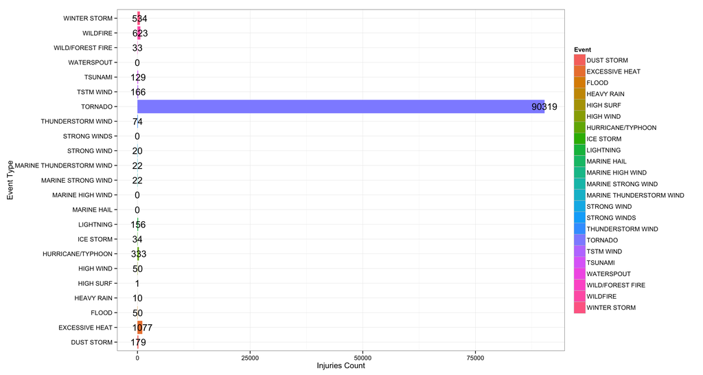

```r
g <- ggplot(data = injur.new, aes(x = injur.new$EVTYPE, y = injur.new$total.count, fill=injur.new$EVTYPE))
g <- g + geom_bar(stat = "identity") + scale_fill_hue(c=45, l=80)
g <- g + geom_text(aes(label = injur.new$total.count, y = injur.new$total.count))
g <- g + coord_flip()
g <- g + scale_fill_discrete(name="Event")
g <- g + xlab("Event Type") +  ylab("Injuries Count")
g <- g + theme_bw()
g
```

Both plots clearly shows that the most harmful event to the human population health is `TORNADO`.

### `ECONOMIC` Processing

For each event, I will sum individual calculation of property and crop damages.

```r
eco.data <- storm.data %>% select(EVTYPE,PROPDMG,PROPDMGEXP,CROPDMG,CROPDMGEXP)

# change the values as per below
# "","+","-","?" = 1 (for consistency purpose)
# "0","1","2","3","4","5","6","7","8" = 10 (for consistency purpose))
# H|h = 100
# K|k = 1000
# M|m = 1000000
# B|b = 1000000000

eco.data$PROPDMGEXP <- mapvalues(eco.data$PROPDMGEXP, from = c("","+","-","0","1","2","3","4","5","6","7","8","?","B","H","K","M","h","m"), to = c("1","1","1","10","10","10","10","10","10","10","10","10","1","1000000000","100","1000","1000000","100","1000000"))

eco.data$CROPDMGEXP <- mapvalues(eco.data$CROPDMGEXP, from = c("","M","K","m","B","?","0","k","2"), to = c("1","1000000","1000","1000000","1000000000","1","10","1000","10"))

eco.data <- mutate(eco.data, prop.damage = PROPDMG * as.numeric(PROPDMGEXP), crop.damage = CROPDMG * as.numeric(CROPDMGEXP), total.damage = prop.damage + crop.damage)

eco.damage <- aggregate(total.damage ~ EVTYPE, data = eco.data, FUN = sum )
eco.damage <- arrange(df = eco.damage, desc(eco.damage$total.damage))

top.20 <- eco.damage[1:20,]
top.20
```

```
##                       EVTYPE total.damage
## 1                      FLOOD 150319678257
## 2          HURRICANE/TYPHOON  71913712800
## 3                    TORNADO  57352117610
## 4                STORM SURGE  43323541000
## 5                       HAIL  18758224587
## 6                FLASH FLOOD  17562132318
## 7                    DROUGHT  15018672000
## 8                  HURRICANE  14610229010
## 9                RIVER FLOOD  10148404500
## 10                 ICE STORM   8967041810
## 11            TROPICAL STORM   8382236550
## 12              WINTER STORM   6715441260
## 13                 HIGH WIND   5908617595
## 14                  WILDFIRE   5060586800
## 15                 TSTM WIND   5038936340
## 16          STORM SURGE/TIDE   4642038000
## 17         THUNDERSTORM WIND   3897965612
## 18            HURRICANE OPAL   3191846000
## 19          WILD/FOREST FIRE   3108626330
## 20 HEAVY RAIN/SEVERE WEATHER   2500000000
```

### `Economic` plot

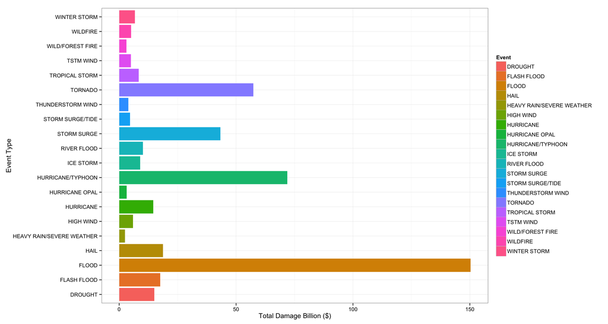

```r
g <- ggplot(data = top.20, aes(x = top.20$EVTYPE, y = top.20$total.damage/1000000000, fill=top.20$EVTYPE))
g <- g + geom_bar(stat = "identity") + scale_fill_hue(c=45, l=80)
g <- g + coord_flip()
g <- g + scale_fill_discrete(name="Event")
g <- g + xlab("Event Type") +  ylab("Total Damage Billion ($)")
g <- g + theme_bw()
g
```

### Results

1. Events `Tornado, Excessive Heat, Heat` are most harmful w.r.t population health
2. Events `Flood, Hurricane/Typhoon, Tornado, Storm Surge` cause greatest economic consequences.